# ggplot2::geom_dotplot()

# Function of the Week: geom_dotplot()

Sifora Lebeneh

2024-02-23

```r
#load tidyverse up
library(tidyverse)
```

```r
library(ggplot2)
library(readxl)
library(glue)
library(Hmisc)
```

# geom_dotplot()

In this document, I will introduce the geom_dotplot() function and show what it’s for.

## What is it for?

> Dot plots are a type of graph that displays the distribution of a variable by placing a dot for each observation along a horizontal axis. The dots are stacked vertically if they have the same value on the x-axis. Dot plots work very well for data with a small number of values. They would not work well for large sets of data, because a dot would need to be plotted for each value.

**Simple data set to understand Dot-Plot**

```r
# student score out of 100
Studnet_score <- data.frame(student = c(1,2,3,4,5,6,7,8,9,10,11,12,13,14,15,16,17,18,19,20,21,22),
  score = c(40, 50, 55, 65, 70, 70, 70, 70, 70, 75, 75, 75, 75, 85, 85, 90, 91, 94, 94, 97, 97, 100))
Studnet_score
```

```
##    student score
## 1        1    40
## 2        2    50
## 3        3    55
## 4        4    65
## 5        5    70
## 6        6    70
## 7        7    70
## 8        8    70
## 9        9    70
## 10      10    75
## 11      11    75
## 12      12    75
## 13      13    75
## 14      14    85
## 15      15    85
## 16      16    90
## 17      17    91
## 18      18    94
## 19      19    94
## 20      20    97
## 21      21    97
## 22      22   100
```

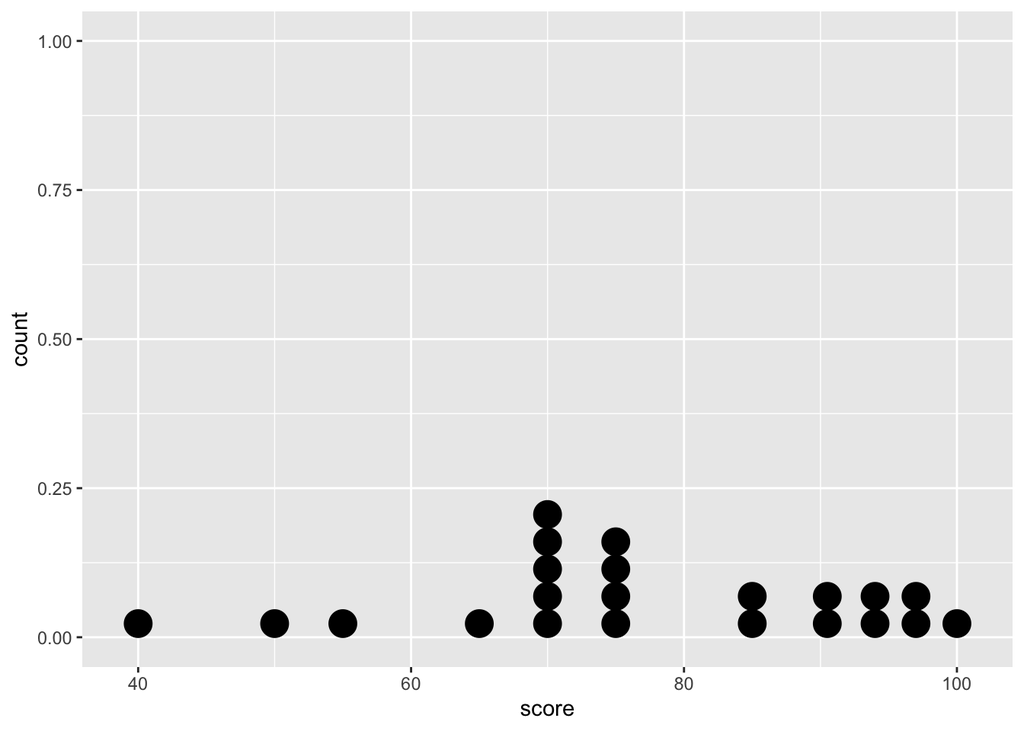

```r
score<-ggplot(Studnet_score, aes(x=score)) +
  geom_dotplot()
score
```

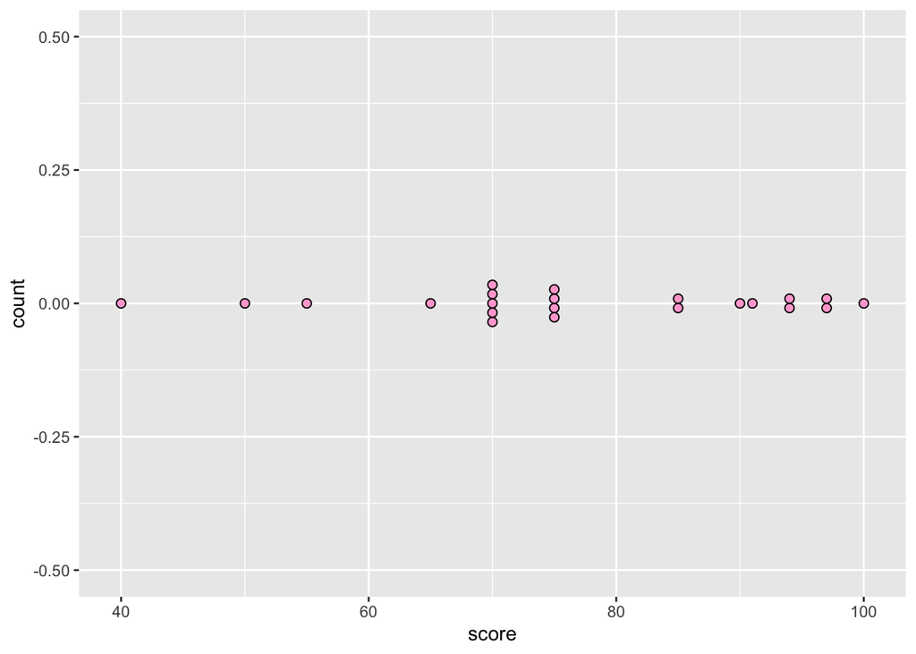

```r
score <- ggplot(Studnet_score, aes(x = score)) +
  geom_dotplot(binwidth = 0.75,
               stackdir = "center", fill="#FFAAD4")
score
```

Data form :- https://www.kaggle.com/datasets/harsh45/random-salary-data-of-employes-age-wise

```r
# Load data Set
Salary_data <- read_csv("~/Downloads/R Programing /sph_r_programming_class_project_folders_2023 (1)/data/Salary_dataset.csv",
    na = "NA")
```

```
## ──────────────────────────────────────────────────────── Delimiter: "," dbl
## (3): ...1, YearsExperience, Salary
```

```r
glimpse(Salary_data)
```

```
## Rows: 30
## Columns: 3
## $ ...1            <dbl> 0, 1, 2, 3, 4, 5, 6, 7, 8, 9, 10, 11, 12, 13, 14, 15, …
## $ YearsExperience <dbl> 1.2, 1.4, 1.6, 2.1, 2.3, 3.0, 3.1, 3.3, 3.3, 3.8, 4.0,…
## $ Salary          <dbl> 39344, 46206, 37732, 43526, 39892, 56643, 60151, 54446…
```

> There are two tye of Dot plot, Wilkinson Dot Plot and cleveland dot plot.

**Wilkinson Dot Plot**

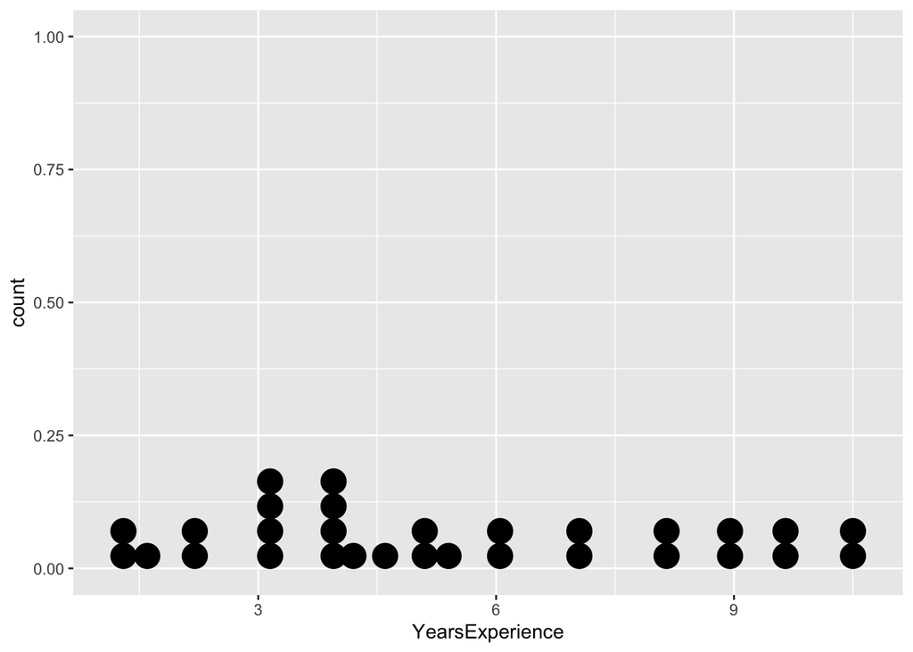

```r
ggplot(Salary_data, aes(YearsExperience))+
  geom_dotplot()
```

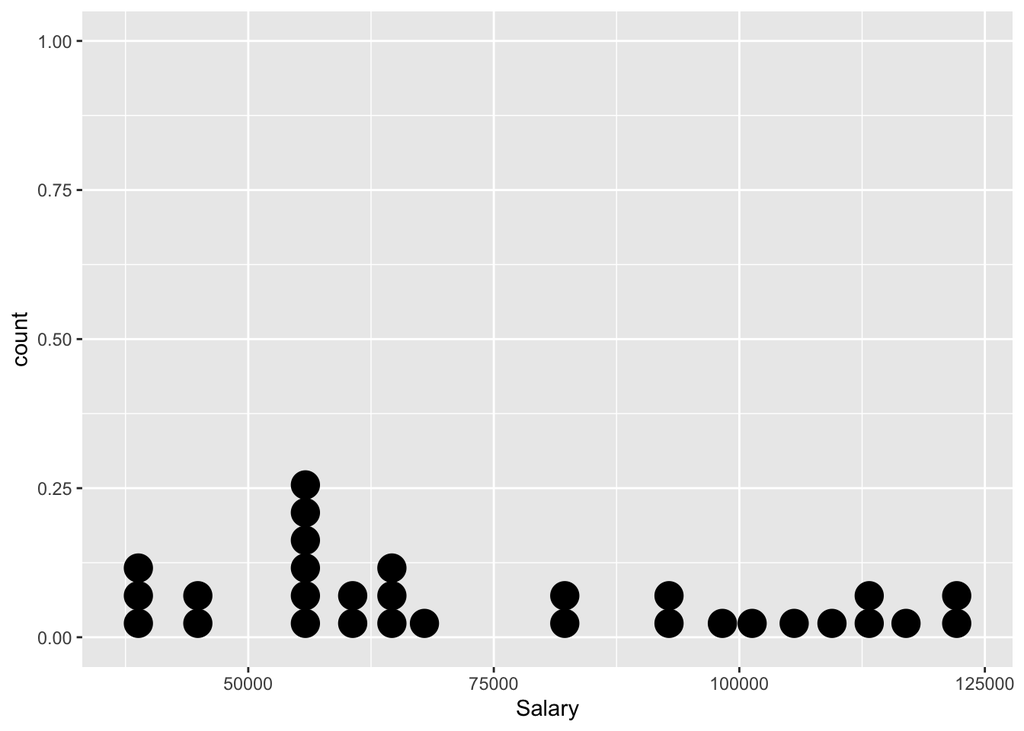

```r
ggplot(Salary_data, aes(Salary))+
  geom_dotplot()
```

**Cleveland Dot Plot**

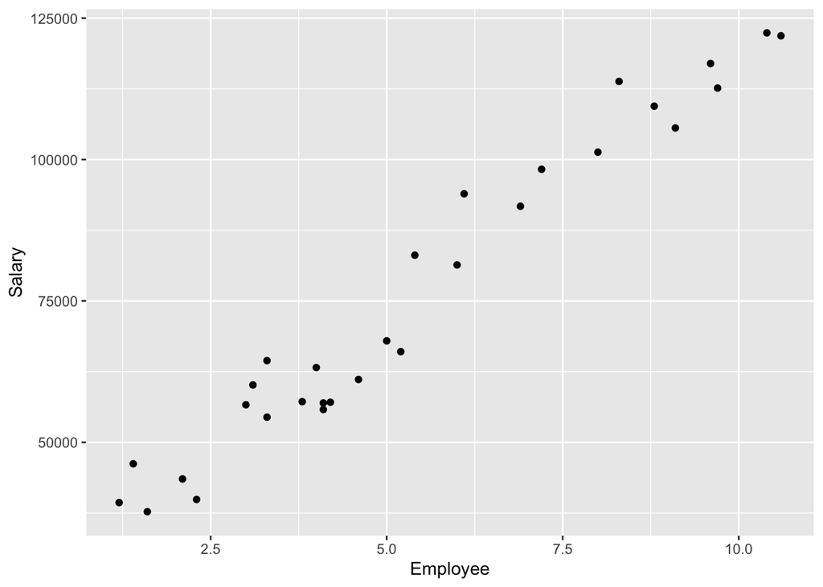

```r
ggplot(Salary_data, aes(x=YearsExperience, y= Salary))+
  geom_point()+
labs(x="Employee")
```

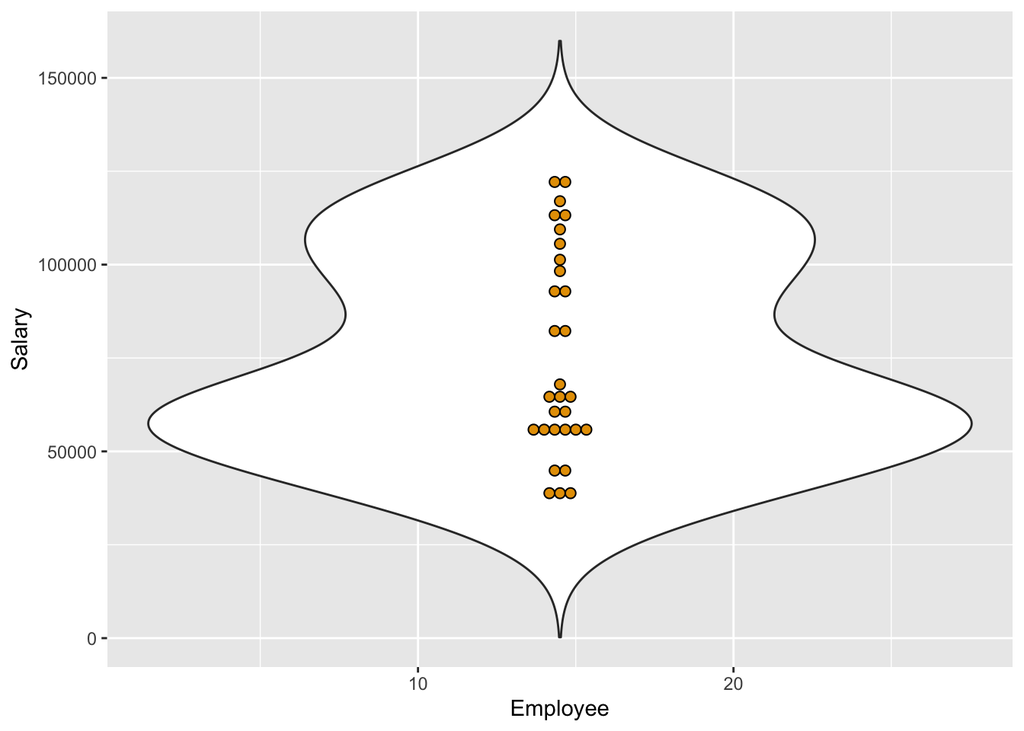

```r
# Add violin plot
C <- ggplot(Salary_data, aes(x=...1, y= Salary)) +
  geom_violin(trim = FALSE)+
 geom_dotplot(binaxis='y', stackdir='center', fill="#E69F00")+
  labs(x="Employee")
C
```

**Adding box plot**

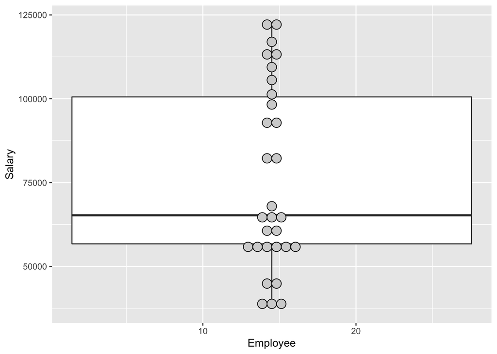

```r
# dot plots combined with box plots
e <- ggplot(Salary_data, aes(x=...1, y= Salary))

e + geom_boxplot(width = 0.5) +
  geom_dotplot(binaxis = "y", stackdir = "center", fill = "lightgray") +
labs(x="Employee")
```

```r
median(Salary_data$Salary)
```

```
## [1] 65238
```

```
## notch went outside hinges. Try setting notch=FALSE.
```

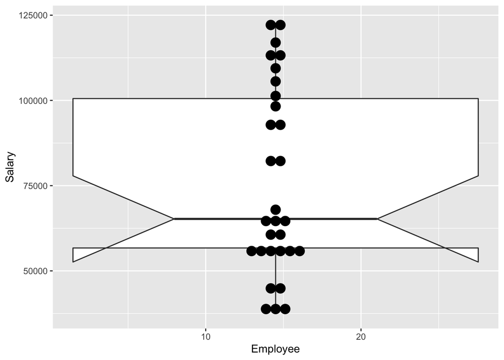

```r
# Add notched box plot
B <- ggplot(Salary_data, aes(x=...1,  y=Salary)) +
  geom_boxplot(notch = TRUE)+
  geom_dotplot(binaxis='y', stackdir = "center")+
  labs(x="Employee")
B
```

## Is it helpful?

> Discuss whether you think this function is useful for you and your work. Is it the best thing since sliced bread, or is it not really relevant to your work?

Yes, dot plots was useful for my data. It was showing me individual data points, unlike other types of plots that aggregate data, such as histograms or box plots, dot plots display each of my individual data point as a dot, which was really helpful for identifying patterns and outliers. It was very easy and clear to read my data.

However, there are also some potential limitations of dot plots, such as the possibility of overplotting when there are many data points, and the difficulty of comparing the distribution of multiple variables or groups on the same plot.

Overall, whether or not dot plots are useful depends on the specific data being analyzed and the research question being addressed. It’s always a good idea to consider different types of plots and choose the one that best suits the data and the purpose of the analysis.

[Edit this page](https://github.com/jminnier/sph_r_programming_site/edit/master/content/functions/ggplot2_geom_dotplot.html)